# Mixed logistic regression

Tutorial 12: exercises and solutions

Dr Massimiliano Canzi

## Setup

```r
library(tidyverse)
library(lme4)
library(simling)
```

## The data

In `vot_identification`, 12 English and 12 Spanish listeners hear syllables like *ba* and *pa* made by a speech synthesiser. The voice onset time (`vot`) of the first consonant goes from −20 to 60 ms in steps of 5 ms. Listeners hear each step 10 times (`trials`) and say each time whether they heard a voiced (*b*) or a voiceless (*p*) consonant; `voiceless` is how often they said *p*. Today we use only the labial consonants, *b* and *p*:

```r
labials <- vot_identification |>
  filter(place == "labial")
glimpse(labials)
```

```
Rows: 408
Columns: 6
$ listener  <fct> En01, En01, En01, En01, En01, En01, En01, En01, En…
$ language  <fct> English, English, English, English, English, Engli…
$ place     <fct> labial, labial, labial, labial, labial, labial, la…
$ vot       <int> -20, -15, -10, -5, 0, 5, 10, 15, 20, 25, 30, 35, 4…
$ trials    <int> 10, 10, 10, 10, 10, 10, 10, 10, 10, 10, 10, 10, 10…
$ voiceless <int> 0, 0, 0, 0, 0, 0, 1, 3, 0, 6, 9, 7, 10, 10, 10, 10…
```

Today’s question: where do English and Spanish listeners put the boundary between *b* and *p*?

# 1. Identification curves

## 1.1 Proportions

Add a column `p`, the proportion of voiceless answers (`voiceless / trials`). Then compute the mean `p` for each `vot` and `language`, and plot it against `vot` with one colour and one line per language.

## 1.1 Solution

```r
labials <- labials |>
  mutate(p = voiceless / trials)
labials |>
  summarise(p = mean(p), .by = c(vot, language)) |>
  ggplot(aes(x = vot, y = p, colour = language)) +
  geom_point(size = 3) +
  geom_line(linewidth = 1) +
  xlab("VOT (ms)") + ylab("Proportion of voiceless answers") +
  theme(legend.position = "right")
```

## 1.1 Solution

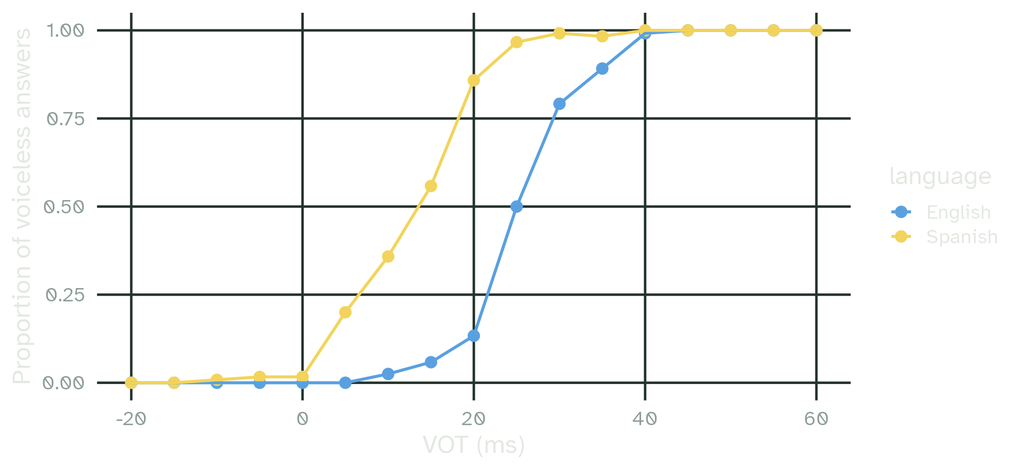

Both groups go from almost always *b* to almost always *p* along an S-shaped curve. The Spanish curve rises at a shorter VOT.

## 1.2 Why not `lm()`?

Why would a straight line be a poor model for these proportions?

## 1.2 Solution

A straight line goes on rising below 0 and above 1, where no proportion can be. The answers flip from *b* to *p* over a narrow range of VOT, and a straight line cannot follow that S-shape.

# 2. A logistic regression

When each row has a number of successes out of a number of trials, `glm()` takes them as `cbind(successes, failures)`: here `cbind(voiceless, trials - voiceless)`.

## 2.1 English listeners

Keep the English listeners, in a data frame `en`. Fit a logistic regression of the voiceless answers as a function of `vot` with `glm()` and `family = binomial`, and print its coefficients.

## 2.1 Solution

```r
en <- labials |>
  filter(language == "English")
g <- glm(cbind(voiceless, trials - voiceless) ~ vot, data = en, family = binomial)
coef(g)
```

```
(Intercept)         vot
 -7.0952569   0.2777905
```

## 2.2 Read the coefficients

The intercept is the log odds of a voiceless answer at a VOT of 0 ms. Turn it into a probability with `plogis()`. Then turn the slope into an odds ratio with `exp()`: what happens to the odds of a voiceless answer with each extra millisecond of VOT?

## 2.2 Solution

```r
plogis(coef(g)[1])
```

```
 (Intercept)
0.0008283411
```

```r
exp(coef(g)[2])
```

```
    vot
1.32021
```

At 0 ms, the model predicts a voiceless answer 0.1% of the time. Each extra millisecond of VOT multiplies the odds of a voiceless answer by 1.32.

## 2.3 The category boundary

The boundary between *b* and *p* is the VOT at which both answers are equally likely: a probability of 0.5, or log odds of 0. Where the intercept plus the slope times `vot` is 0, `vot` is −intercept / slope. Compute the boundary. Lisker and Abramson found it at about 25 ms for English labials.

## 2.3 Solution

```r
-coef(g)[1] / coef(g)[2]
```

```
(Intercept)
   25.54176
```

The boundary lies at 25.5 ms, close to 25 ms.

# 3. A mixed logistic regression

## 3.1 Listeners differ

Each listener answers many times, so fit the model again with `glmer()`, with a varying intercept and a varying slope for `vot` by listener. Compare the fixed effects and the boundary with those of `g`.

## 3.1 Solution

```r
m_en <- glmer(cbind(voiceless, trials - voiceless) ~ vot + (1 + vot | listener),
              data = en, family = binomial)
fixef(m_en)
```

```
(Intercept)         vot
 -7.9672798   0.3134817
```

```r
-fixef(m_en)[1] / fixef(m_en)[2]
```

```
(Intercept)
   25.41545
```

The slope is steeper than in `g`: each listener switches from *b* to *p* more abruptly than the pooled curve suggests, because listeners put their boundaries in slightly different places. The boundary is about the same.

## 3.2 Two languages

Fit a mixed model to all labial data, with `vot` and `language` as predictors and the same random effects. Compute the boundary of each language. Spanish listeners should put it at a shorter VOT, about 14 ms.

## 3.2 Solution

```r
m_lang <- glmer(cbind(voiceless, trials - voiceless) ~ vot + language + (1 + vot | listener),
                data = labials, family = binomial)
b <- fixef(m_lang)
b
```

```
    (Intercept)             vot languageSpanish
     -8.3073724       0.3256049       4.0588353
```

```r
c(English = -b[[1]] / b[[2]], Spanish = -(b[[1]] + b[[3]]) / b[[2]])
```

```
 English  Spanish
25.51366 13.04814
```

The Spanish boundary is about 12 ms earlier than the English one.

## 3.3 Test the difference

Fit the model without `language` and compare the two models with `anova()`. Do the languages differ?

## 3.3 Solution

```r
m_vot <- glmer(cbind(voiceless, trials - voiceless) ~ vot + (1 + vot | listener),
               data = labials, family = binomial)
lrt <- anova(m_vot, m_lang)
lrt
```

```
Data: labials
Models:
m_vot: cbind(voiceless, trials - voiceless) ~ vot + (1 + vot | listener)
m_lang: cbind(voiceless, trials - voiceless) ~ vot + language + (1 + vot | listener)
       npar    AIC    BIC  logLik -2*log(L)  Chisq Df Pr(>Chisq)
m_vot     5 464.81 484.87 -227.41    454.81
m_lang    6 438.71 462.78 -213.36    426.71 28.101  1  1.151e-07 ***
---
Signif. codes:  0 '***' 0.001 '**' 0.01 '*' 0.05 '.' 0.1 ' ' 1
```

They do: χ²(1) = 28.1, p < .001.

# 4. Weekly assignment

Exercises 4.1 to 4.3 are this week’s assignment. Complete them at home, in a file started from the konstats template “Weekly assignment” (tutorial 1), and hand in the .Rmd file within a week.

In `speech_to_song`, 86 listeners hear spoken sentences repeated eight times. For some listeners, a repeated sentence starts to sound like song: `transformed` is 1 if a listener said it did. Each sentence comes in three versions (`manipulation`): unchanged (`baseline`), with flattened pitch within syllables (`pitch`), or with lengthened vowels and other sonorous sounds (`duration`).

## 4.1 Proportions

Compute the proportion of transformed sentences in each version. Which version turns into song most often?

## 4.2 The model

Fit a mixed logistic regression of `transformed` as a function of `manipulation`, with varying intercepts for `listener` and `sentence`. Use `plogis()` to turn the fixed effects into the predicted probability of a transformation in each version, and `exp()` to give the odds ratio of the `pitch` version against the baseline. Report both in a sentence.

## 4.3 A likelihood ratio test

Compare your model with a model without `manipulation`, with the same random effects. Do the versions differ? Report χ², the degrees of freedom and p.

## Reading

This tutorial goes with chapter 12 and section 15.8 of Winter (2019).

Winter, B. (2019). *Statistics for linguists: An introduction using R*. Routledge. https://doi.org/10.4324/9781315165547

## Slides and exercises

[figure not shown]

These slides

mcanzi.de/statistics/tutorials/12_logistic_regression.html

Exercise sheet (R Markdown)

mcanzi.de/statistics/tutorials/12_logistic_regression.Rmd